# PARTS Simulations

Clay Morrow

3/10/2021

```r
require("mvtnorm")
library(dplyr)
library(ggplot2)
```

# Reworked models

The overall response will be simulated with the following process:

$$x_{i}(t) = \beta_{k, i}u_{k, i} + (\phi_{m, i}u_{m,i})t +
\gamma_{k, i} w_{k, i}(t) + \varepsilon_{i}(t) \tag{1}$$

Where:

- $x_{i}(t)$ is the variable of interest (e.g. NDVI) in pixel $i$;
- $u_{k,i}$ is a model matrix of $k = 1, ..., K$ spatially variable predictors (e.g. landclass);
- $w_{m, i}(t)$ are $m = 1, ..., M$ spatio-temporally variable predictors (e.g. temperature);
- $\beta_{k, i}$, $\phi_{m, i}$, and $\gamma_{m, i}$ are the effects of the predictors. Each of these can be fixed OR randomly distributed in space $\{\beta_{k}, \phi_{m}, \gamma_{m} \} \sim N(\mu, \Sigma_\text{Matern})$ (see below); and
- $\varepsilon_{i}(t)$ is the spatio-temporally correlated error term.

$\varepsilon_{i}(t)$ (and $w_{m,i}$) is generated with an ARMA process:

$$\varepsilon_{i}(t) = \delta_{i}(t) +
\sum_{j = 1}^{p}{\rho_{j}\varepsilon_{i}(t)} +
\sum_{j = 1}^{q}{\theta_{j}\varepsilon_{i}(t)} \tag{2}$$

where:

- $\sum_{j = 1}^{p}{\rho_{j}\varepsilon_{i}(t)}$ is the AR(p) process;
- $\sum_{j = 1}^{q}{\theta_{j}\varepsilon_{i}(t)$ is the MA(q) process; and
- $\delta_{i}(t) \sim N(0, \Sigma_{\delta_{i}})$ are spatially correlated errors;

Spatial correlation in the ARMA terms is generated with an exponential power function:

$$\Sigma_{\delta_{i}} = I\eta_i + (\sigma^{2} - \mu_{\eta_i})exp{(-d_{i, j}/r)^a} \tag{3}$$

where:

- $I\eta_{i}$ is an Identity matrix multiplied by the nugget $\eta_{i}$, which may be fixed OR variable in space: $\eta_{i} \sim N(0, \Sigma_{\text{Matern}})$;
- $\sigma^2$ is the sill (variance) of $\delta_i$ (I’ll stick with unit variance);
- $d_{i, j}$ is the distance between pixels $i$ and $j$;
- $r$ is the range of the spatial auto-correlation (in pixels); and
- $a$ is the shape parameter for the auto-correlation function

Other spatial correlations $\Sigma_{\text{Matern}} = R(h)$ will be generated the Matern Cross-covariance function:

$$R(d_{i, j}; v, c) = 2^{1-v} \Gamma(v)^{-1}(c||d_{i, j}||)^{v} K_{v}(c||d_{i, j}||) \tag{4}$$
where :

- $c > 0$ is the scale parameter (similar to range $r$)
- $v > 0$ is the smoothness parameter. When $v = \frac{1}{2}$, $R(h)$ is equivalent to $exp(d_{i, j} / c)$ and $\lim_{v \to \infty} R(h) = exp(-d/2c)^2$
- $\Gamma$ is the gamma function, and
- $K$ is a modified Bessel function of the second kind

**Note:** In practice, this function is very useful for generating smooth spatial correlations and waves (see $\S$ “Spatially variable parameter” below). But may need some help understanding the math and what it’s actually doing! It may be worth while to also generate $\delta_{i}$ with Matern correlations?

# Simulation Plans

## Data Generation

In order to vigorously test the robustness of the PARTS method, we will simulate 1000 sets of predictor variables $u_{k,i}$ and $w_{m,j}$ and varying the effects that each of those sets have on $x_i(t)$. Therfore, $x$ will be simulated $1000$ for each unique set of effect parameter combinations. The map for all simulations will be the same size: $20\times20$ pixels (or some other size, dependant on speed). $d_{i, j}$ will contain the Euclidean distance between points and will be constant throughout the simulations.

$u$ will represent land cover class designations, with 4 levels ($m = 4$), coded as dummy variables (i.e. $\{0, 1\}$). It will be generating by discretizing (by quartiles) a continuous variable produced with the Matern covariance function. $c$ and $v$ will be selected to generate a desired spatial pattern and will be constant throughout the simulations. $u$ will have no nugget and unit variance (i.e. $\eta = 0$, $\sigma^2 = 1$).

$w$ will be a single ($k = 1$) spatio-temporal variable representing temperature. It will be generated as an ARMA(1, 1) model with Matern covariance structure. $c$ and $v$ will be selected to generate a desired spatial pattern (different from $u$) and will be constant throughout the simulations. $\rho$ and $\theta$ will also be predetermined and constant. $w$ will have unit variance. $w$ will have no nugget and unit variance (i.e. $\eta = 0$, $\sigma^2 = 1$).

$x$ will then be generated, for 30 time points ($t = 1, ..., 30$), by varying the following parameters on each of the 1000 data sets. This will allow us to compare the effect of the parameter independent of the specific predictor values.

Effects parameters $\beta$, $\phi$, and $\gamma$, will take on one of 3 levels: 2 fixed values (i.e. $\{0, 0.5\}$) and one spatially distributed random variable (i.e. $\sim N(0.5, \Sigma_{\text{Matern}})$). The AR parameter $\rho$ will also have 2 levels (e.g. $\{\rho_1 = .6, \rho_2 = .3\}$ and $\{\rho_1 = .8, \rho_2 = .1\}$), the MA parameter $\theta$ will have 2 levels (e.g $\{.1, .5\}$), the spatial nugget $\eta$ will have 2 levels (i.e. $\{0, 0.5\}$), and the spatial correlation range parameter $r$ will have 2 levels (i.e. $\{0.2, 0.5\}$). The spatial correlation shape parameter $a = 2$ will remain constant througout the simulations.

## Model Fitting

For each simulation of $x$, we will apply the PARTS method. We will use AR_REML to fit a time series to each pixel and then will fit a GLS to slope parameters for the effect of time. We will then compare the overall estimate of the effect of time to the true values $(\phi_{m, i})$. If $\phi_m$ was spatially variable, we will compare to the mean $\phi_m$. We will also estimate type I error rates for the case when $\bar{\beta_m} = \bar{\phi_m} = \bar{\gamma_k} = 0$.

# Example Code

This is some code I ran to test out the spatial correlation functions

First we’ll set the initial parameters:

```r
#---
## Initial Parameters
#---

set.seed(3654)

# Sim pars ----
burn.in = 0
sim.iters = 1

# Map pars ----
map.cols = 20
map.rows = 10
npix = map.rows * map.cols # should be a square

# ARMA pars ----
rhos = c(0.6, 0.2)# AR parameter(s): must sum to less than 1
thetas = c(.4) # MA parameter: must be less than 1

# Temporal pars ----
ntime = 30 # number of time points

# varcov pars ----
cormod = "stable" # 'stable' correlation model: varcov = nug+sill*exp(-(d/scale)^shape)
dist.meth = "Eucl" # Euclidean distance
sill = 1 # sill (variance)
r = .25 # range of spatial autocor, relative to width of map (scale parameter)
a = 1 # shape of spatial autocor function (shape parameter)
nug = .2 # fixed nugget

# spatial nugget pars ----
nug.cormod = "matern"
nug.distmeth = "Eucl"
nug.r = .2
nug.s = 20
constrain.nug = c(0, 1) # constrain the spatial nugget to these values

# effect parameters ----
beta = .2 # spatial predictors
phi = .2 # spatio-temporal predictors
gamma = .5 # time trends

# Additinal parameter calculations ----

## Assign coordinates to pixels
coords = as.matrix(expand.grid(x = as.double(1:map.cols),
                               y = as.double(1:map.rows)))

## spatial correlation
psill = sill - nug # partial sill: if nug is spatially variable, use mean(nug)
range = r * map.cols # range in pixels

## spatially variable parameters
nug.range = nug.r * map.cols
nug.smooth = nug.s


# Sanity checks ----
stopifnot(sum(rhos) < 1)
stopifnot(nrow(coords) == npix)

# parameter table ----

fixed.pars = expand.grid(range = range, a = a, nug = nug, fixed.pars = TRUE)


corpars = list(scale = range, power = a, # parameter list for Covmatrix()
               sill = psill, nugget = nug, mean = 0)
nugpars = list(scale = nug.range, smooth = nug.smooth,
               mean = 0, sill = 1, nugget = 0)
```

Then:

1. Calculate the spatial covariance matrix $\Sigma_{\delta_{i}}$ with the function `Covmatrix` from package `CompRandFld`.

```r
start.time = Sys.time()

# Calculate varcov matrix (Sigma) ----
## Covmatrix() - easier to modify specs
covmat = CompRandFld::Covmatrix(coordx = coords,
                                 distance = dist.meth,
                                 corrmodel = cormod,
                                 param = corpars)$covmatrix
# invcholV = remotePARTS::invert_chol(covmat)

# ## Tony's
# d = as.matrix(stats::dist(coords, method = "euc"))
# d.scale = (d - min(d)) / (max(d) - min(d)) # rescale to (0, 1)
# covmat2 = diag(rep(nug, npix)) + (1 - nug) * exp(-(d/r)^a)
# invcholV2 = remotePARTS::invert_chol(covmat2)
# ## Same answer?
# all((covmat2 - covmat) == 0) # TRUE! - also no speed change
```

2. generate $\delta_i$ with `rmvmnorm()`.

```r
# Generate spatially correlated errors (delta) ----
del = mvtnorm::rmvnorm(n = ntime, sigma = covmat, method = "chol")
```

3. generate $\varepsilon_{i}(t)$.

```r
# Generate ARMA errors (epsilon) ----
## apply arima.sim() to each column of del
eps = t(apply(X = del, MARGIN = 2,
             function(e){
               arima.sim(n = ntime,
                         model = list(ar = rhos, ma = thetas),
                         innov = e)
             }))

end.time = Sys.time()
```

```r
end.time - start.time # 3.42 minutes
```

```
## Time difference of 0.7662461 secs
```

Let’s visualize the correlations among $\varepsilon_{i}(t)$ in space and time:

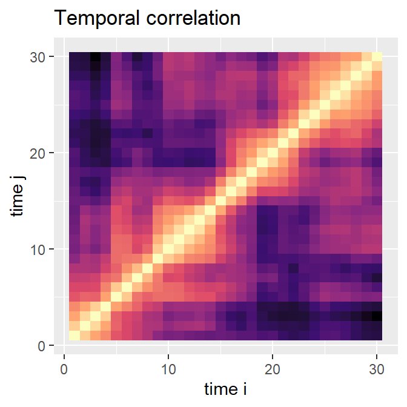

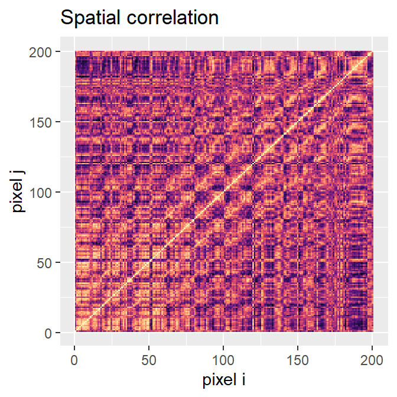

4. Add the errors to the rest of the sim model

```r
# beta, phi, gamma: user defined effects parameters (possibly spatially variable)
# u: spatially generated predictors (via mattern function)
# m: spatio-temporally generated predictors (mattern & ARMA functions)

x = beta*u +  phi*u*time  + gamma*w + eps

#Note: proper matrix multiplication will be used
```

# Spatially variability: Matern Covariance

To demonstrate how we can simulate a waved spatial pattern in our predictors and effects parameters, I’ll now generate a spatially variable nugget using Matern cross-covariance. When $v$ and $c$ are both large, you get a wave across the map:

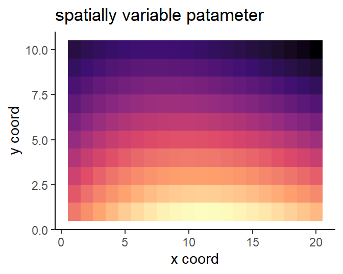

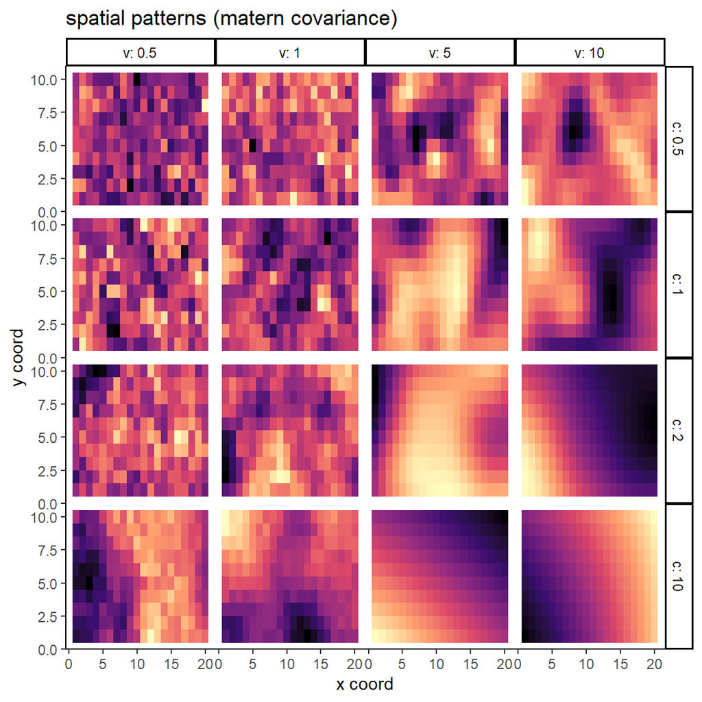

whereas the stable exponential function has more limited range ($0<a\leq2$). Though, the Gaussian version ($a = 2$) can generate interesting and realistic patterns:

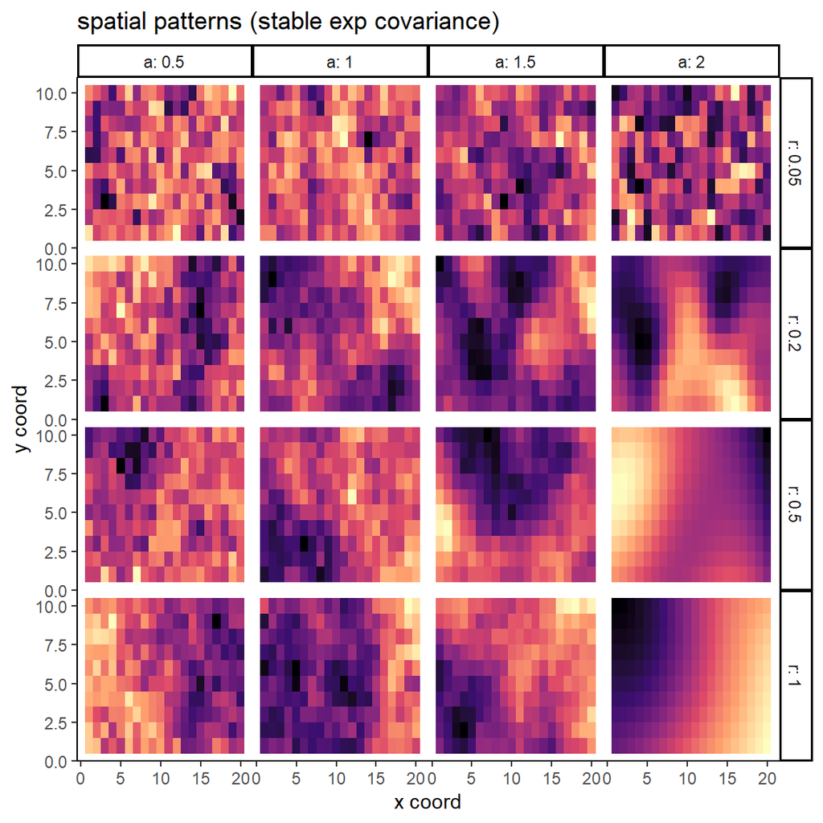

```r
r.tmp = c(.05, 0.2, .5, 1)*map.cols

a.tmp = c(.5, 1, 1.5, 2)

spatcor.tab = data.frame(NULL)

for (a in a.tmp) for (r in r.tmp){

  nugpars = list(scale = r, power = a,
               mean = 0, sill = 1, nugget = 0)

  nug.vcov = CompRandFld::Covmatrix(coords,
                                    distance = dist.meth,
                                    corrmodel = "stable",
                                    param = nugpars)$covmatrix
  # image(nug.vcov)
  spat.nug <- scales::rescale(mvtnorm::rmvnorm(n = 1, sigma = nug.vcov), to = constrain.nug)
  tmp = data.frame(coords, nug = as.vector(spat.nug), r = r/map.cols, a = a)
  spatcor.tab = rbind(spatcor.tab, tmp)

  # nug.corpars = list(scale = range, power = a, sill = psill, nugget = 0, mean = 0)
  # covmat = CompRandFld::Covmatrix(coordx = coords,
  #                                 distance = dist.meth,
  #                                 corrmodel = cormod,
  #                                 param = nug.corpars)$covmatrix
  #
  # covmat = diag(as.vector(spat.nug)) + (1-mean(as.vector(spat.nug)))*covmat
  # del = mvtnorm::rmvnorm(n = ntime, sigma = covmat, method = "chol")
  # eps = t(apply(X = del, MARGIN = 2,
  #               function(e){
  #                 arima.sim(n = ntime,
  #                           model = list(ar = rhos, ma = thetas),
  #                           innov = e)
  #               }))

}

ggplot(data = spatcor.tab, aes(x = x, y = y, fill = nug)) +
  theme_classic() +
  theme(legend.position = "none",
        panel.spacing = unit(0, "lines")) +
  geom_tile() +
  scale_fill_viridis_c(option = "magma") +
  facet_grid(r ~ a, labeller = "label_both") +
  labs(x = "x coord", y = "y coord", title = "spatial patterns (stable exp covariance)")
```

The matern covariance structure seems to have been developed to generate more bioligically realistic spatial patterns.